# Ford GoBike System Review

## by Onyeukwu Stephen

## Investigation Overview

> The main focus in this presentation is trip duration across days of the week, hours of the day as well as the user type present in Ford Gobike.

## Dataset Overview

> The Ford GoBike System Dataset is a dataset that provides information about the bike sharing service provided by Ford GoBike. The data includes information about bike trips such as the start and end time, start and end station, trip duration, and user type. It also includes information about the user, such as their age, gender, and type of subscription. The dataset can be used to analyze and understand the usage patterns and preferences of Ford GoBike users. Some common use cases for this dataset include analyzing the demand for bike sharing services, identifying the busiest stations and times, and understanding the demographic of users.

## Percentage of User type

> In February 2019, subscribers accounted for the vast majority of bike usage, approximately 91%, while customers accounted for approximately 9%.

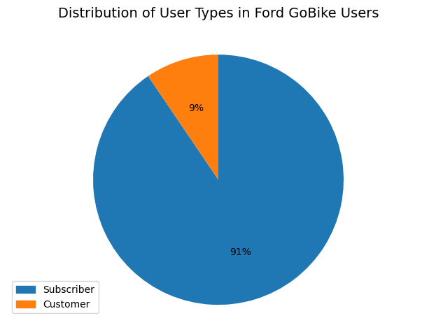

## Distribution of Rides by Day

> Thursday and Tuesday had the highest number of rides, the least number of rides are taken o weekends.

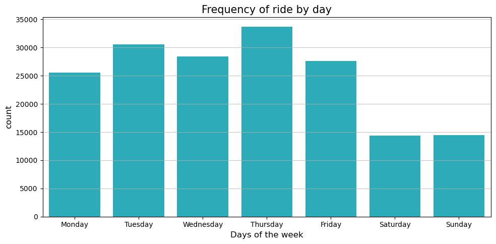

## Distribution of Rides by Hour

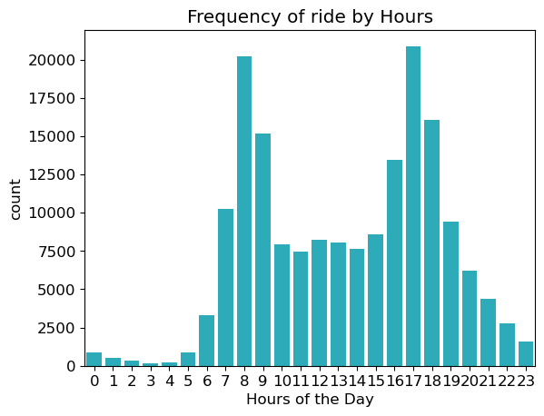

## Distribution of Rides across user type

> Compared to subscribers, customers tend to spend more time on each trip.

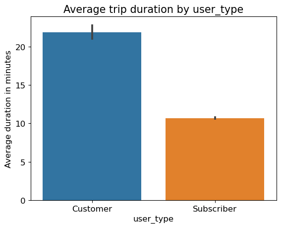

## Variation of trip duration across days and user type

> Compared to regular customers, subscribers take faster trips every day of the week. The duration of trips tends to increase on weekends for both user categories, particularly for customers. The average trip time for subscribers is notably more consistent from Monday to Friday, compared to all customers.

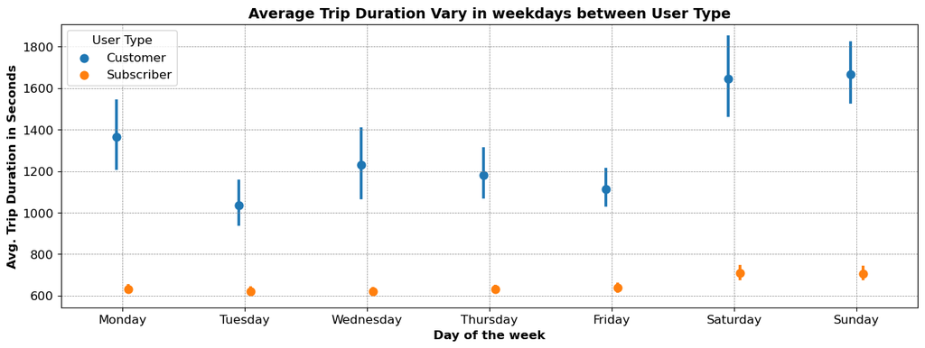